# *Ford GoBike System Data* Dataset Exploration

# Preliminary Wrangling

This document explores a dataset containing users and trips data for approximately 170,999 trips in September 2019 in San Francisco,US.

**Importing the libraries, loading the dataset and making an overview.**

```python
# import all packages and set plots to be embedded inline
import numpy as np
import pandas as pd
import matplotlib.pyplot as plt
import seaborn as sb
import time

%matplotlib inline
```

```python
# load in the dataset into a pandas dataframe, print statistics
bikes = pd.read_csv('./bikes.csv')
```

```python
# high-level overview of data shape and composition
print(bikes.shape)
print(bikes.dtypes)
print(bikes.head(10))
```

```
(170999, 14)
Unnamed: 0                   int64
duration_sec                 int64
weekdays_start              object
start_station_name          object
end_station_name            object
bike_id                      int64
user_type                   object
member_gender               object
bike_share_for_all_trip     object
duration_sec_log           float64
duration_sec_sqrt          float64
duration_sec_cbrt          float64
member_age                 float64
age_grouped                 object
dtype: object
   Unnamed: 0  duration_sec weekdays_start  \
0           0         60863         Monday
1           2          5615         Monday
2           4          1272         Monday
3           6           644         Monday
4           7           459         Monday
5           8           625         Monday
6          11           218         Monday
7          12           471         Monday
8          13           146         Monday
9          14           823         Monday

                                  start_station_name  \
0  San Francisco Caltrain Station (King St at 4th...
1                                Jones St at Post St
2                              Sanchez St at 15th St
3  San Francisco Ferry Building (Harry Bridges Pl...
4                                   5th St at Folsom
5                            Steuart St at Market St
6                        S Van Ness Ave at Market St
7                          Fulton St at Bancroft Way
8                                 West St at 40th St
9                               Market St at 45th St

```

[output cut: 20 more lines]

```
7          Male                      No          6.154858          21.702534
8          Male                      No          4.983607          12.083046
9          Male                      No          6.712956          28.687977

   duration_sec_cbrt  member_age age_grouped
0          39.335480        29.0       18-29
1          17.773921        34.0       30-39
2          10.835003        30.0       18-29
3           8.635655        38.0       30-39
4           7.713845        25.0       18-29
5           8.549880        34.0       30-39
6           6.018462        44.0       40-49
7           7.780490        33.0       30-39
8           5.265637        30.0       18-29
9           9.371302        23.0       18-29
```

```python
bikes = bikes.drop(columns=['Unnamed: 0'])
bikes.head(3)
```

|  | duration_sec | weekdays_start | start_station_name | end_station_name | bike_id | user_type | member_gender | bike_share_for_all_trip | duration_sec_log | duration_sec_sqrt | duration_sec_cbrt | member_age | age_grouped |
| --- | --- | --- | --- | --- | --- | --- | --- | --- | --- | --- | --- | --- | --- |
| 0 | 60863 | Monday | San Francisco Caltrain Station (King St at 4th... | San Francisco Caltrain Station (King St at 4th... | 12904 | Customer | Female | No | 11.016381 | 246.704276 | 39.335480 | 29.0 | 18-29 |
| 1 | 5615 | Monday | Jones St at Post St | Cyril Magnin St at Ellis St | 10737 | Customer | Male | No | 8.633197 | 74.933304 | 17.773921 | 34.0 | 30-39 |
| 2 | 1272 | Monday | Sanchez St at 15th St | Valencia St at 21st St | 1349 | Subscriber | Male | No | 7.148346 | 35.665109 | 10.835003 | 30.0 | 18-29 |

```python
numeric_vars = ['duration_sec_log','member_age']
categoric_vars = ['weekdays_start', 'user_type', 'member_gender']
```

**Some preliminary wrangling were made previosly, I describe below some examples of code, being bike_2019_09 the original dataset:**

```
#creates a column for members age
bike_2019_09['member_age'] = 2019-bike_2019_09['member_birth_year']
```

```
#Groups ages in clusters:
bins = [18, 30, 40, 50, 60, 70, 120]
labels = ['18-29', '30-39', '40-49', '50-59', '60-69', '70+']
bike_2019_09['age_grouped']= pd.cut(bikes['member_age'], bins, labels = labels,include_lowest = True)
```

```
#Transform objects in datetime and checks:
bike_2019_09['start_time'] = pd.to_datetime(bike_2019_09.start_time)
bike_2019_09['end_time'] = pd.to_datetime(bike_2019_09.end_time)
```

**Sorting the variables in proper types.**

```python
# sorts the variables in proper types
ordinal_var_dict = {'weekdays_start': ['Monday','Tuesday','Wednesday','Thursday','Friday','Saturday','Sunday']}

nominal_var_dict = {'user_type': ['Customer','Subscriber'],
                    'member_gender': ['Female', 'Male', 'Other'],
                    'age_grouped':['18-29', '30-39', '40-49', '50-59', '60-69', '70+']}


for var in ordinal_var_dict:
    ordered_var = pd.api.types.CategoricalDtype(ordered = True,
                                                categories = ordinal_var_dict[var])
    bikes[var] = bikes[var].astype(ordered_var)

for var in nominal_var_dict:
    ordered_var = pd.api.types.CategoricalDtype(ordered = True,
                                                categories = nominal_var_dict[var])
    bikes[var] = bikes[var].astype(ordered_var)
```

```python
print(bikes.dtypes)
```

[output not shown]

```python
bikes.shape
```

```
(170999, 13)
```

**Analyzing the Statistics.**

```python
# descriptive statistics for numeric variables
print(bikes.describe())
```

```
        duration_sec        bike_id  duration_sec_log  duration_sec_sqrt  \
count  170999.000000  170999.000000     170999.000000      170999.000000
mean      713.529763    7286.698413          6.308851          24.825320
std      1402.360424    4404.651340          0.664465           9.860721
min        61.000000      12.000000          4.110874           7.810250
25%       358.000000    2446.000000          5.880533          18.920888
50%       560.000000    9777.000000          6.327937          23.664319
75%       851.000000   10636.000000          6.746412          29.171904
max     85035.000000   13007.000000         11.350818         291.607613

       duration_sec_cbrt     member_age
count      170999.000000  170999.000000
mean            8.397959      33.914947
std             1.997118      10.155251
min             3.936497      18.000000
25%             7.100588      27.000000
50%             8.242571      31.000000
75%             9.476396      39.000000
max            43.974331     129.000000
```

### What is the structure of your dataset?

Weekdays is a categorical ordinal variable,user_type, member_gender, and age_grouped are categorical nominals, and the oder variables are numericals.

### What is/are the main feature(s) of interest in your dataset?

I'm most interested in figuring out the customer profile.

### What features in the dataset do you think will help support your investigation into your feature(s) of interest?

I expect that age and gender can affect usertype and duration of trips. I also want to discover the trends of use of the bike during the weekdays by type of user.

## Univariate Exploration

**In this section, first I comprare transformations of trips duration and than I investigate distributions of individual variables regarding outliers, cleaning and preparation of data.**

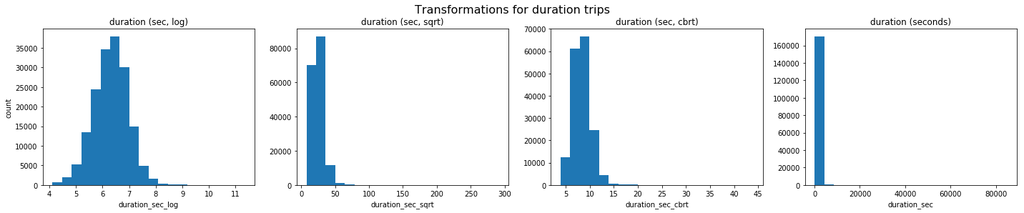

```python
#Transformations for duration
fig, (ax1, ax2,ax3, ax4) = plt.subplots(nrows=1, ncols=4,figsize = [20,4])
base_color = sb.color_palette()[0]
plt.suptitle('Transformations for duration trips',  fontsize=16, y=1.025)

ax1 = plt.subplot(1,4,1)
ax1 = bikes['duration_sec_log']=np.log(bikes['duration_sec'])
ax1 = bikes['duration_sec_log'].hist(bins=20)
ax1.title.set_text('duration (sec, log)')
ax1.set_xlabel('duration_sec_log')
ax1.set_ylabel('count')
ax1.grid(False)

ax2 = plt.subplot(1,4,2)
ax2 = bikes['duration_sec_sqrt']=np.sqrt(bikes['duration_sec'])
ax2 = bikes['duration_sec_sqrt'].hist(bins=20)
ax2.title.set_text('duration (sec, sqrt)')
ax2.set_xlabel('duration_sec_sqrt')
ax2.grid(False)

ax3 = plt.subplot(1,4,3)
ax3 = bikes['duration_sec_cbrt']=np.cbrt(bikes['duration_sec'])
ax3 = bikes['duration_sec_cbrt'].hist(bins=20)
ax3.title.set_text('duration (sec, cbrt)')
ax3.set_xlabel('duration_sec_cbrt')
ax3.grid(False)

ax4 = plt.subplot(1,4,4)
ax4 = bikes['duration_sec']
ax4 = bikes['duration_sec'].hist(bins=20)
ax4.title.set_text('duration (seconds)')
ax4.set_xlabel('duration_sec')
ax4.grid(False)

plt.tight_layout()
```

```python
print( bikes['duration_sec_log'].mean(), bikes['duration_sec_sqrt'].mean(),bikes['duration_sec_cbrt'].mean())
```

```
6.3088506865766165 24.825320176456913 8.39795881014456
```

log is the best transformation to deal with duration_sec. The oders are too skeewed and hard to interprete.

### Analyzing frequences

**I start by looking at the variables: member_gender, member_age and user_type.**

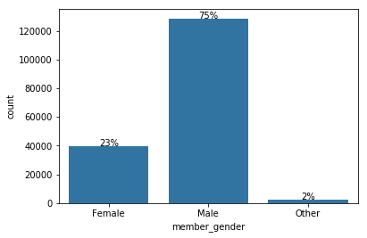

```python
# create the plot
base_color = sb.color_palette()[0]
sb.countplot(data = bikes, x = 'member_gender', color = base_color)

# add annotations
n_points = bikes.shape[0]
cat_counts = bikes['member_gender'].value_counts()
locs, labels = plt.xticks() # get the current tick locations and labels

# loop through each pair of locations and labels
for loc, label in zip(locs, labels):

    # get the text property for the label to get the correct count
    count = cat_counts[label.get_text()]
    pct_string = '{:0.0f}%'.format(100*count/n_points)

    # print the annotation just below the top of the bar
    plt.text(loc, count-8, pct_string, ha = 'center', color = 'black')
```

The number of men is really greaten than women. The gender Other is insignificant.

**Ploting bargraphs for number of trips by members age and by age grouped.**

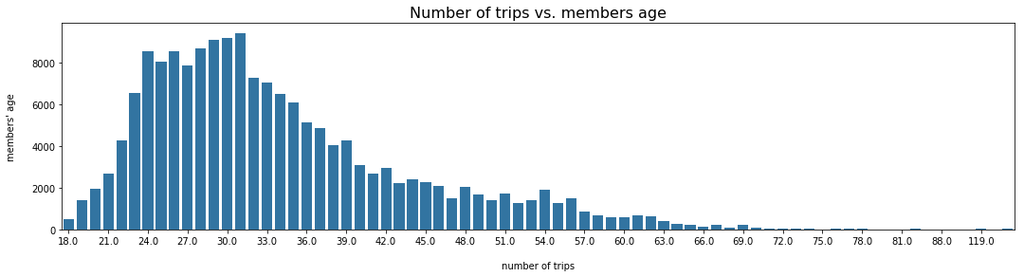

```python
bikes["member_age_new"] = np.where(bikes["member_age"] >= 100, 100,  bikes["member_age"] )

# create the plot
plt.figure(figsize = [18,4])
base_color = sb.color_palette()[0]
sb.countplot(data = bikes, x = 'member_age', color = base_color)


# add annotations
#n_points = bikes.shape[0]
#cat_counts = bikes['member_age'].value_counts()
#locs, labels = plt.xticks() # get the current tick locations and labels

# ensure that the labels are created:
plt.draw()
# get x tick labels and position
loc, label = plt.xticks()
# set the xticks for every second (original) xtick
plt.xticks(loc[::3],label[::3])

plt.title('Number of trips vs. members age', fontsize=16, y=1.015)
plt.ylabel("members' age", labelpad=16)
plt.xlabel('number of trips', labelpad=16)


# loop through each pair of locations and labels
for loc, label in zip(locs, labels):
    # get the text property for the label to get the correct count
    count = cat_counts[label.get_text()]
    pct_string = '{:0.0f}%'.format(100*count/n_points)
```

The histogram is skewed right, so the mean is greater than the median.  
The majority of frequence in trips was found between member of 22 and 39 years old.

**Number of trips vs. members' age**

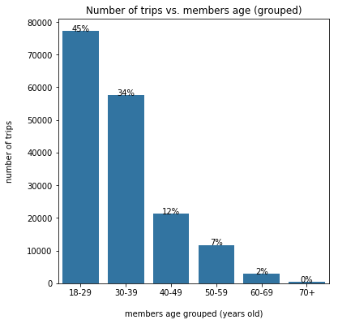

```python
plt.figure(figsize=(6,6))
sb.countplot(data = bikes, x = 'age_grouped', color = base_color)

plt.title('Number of trips vs. members age (grouped)')
plt.xlabel('members age grouped (years old)', labelpad=16)
plt.ylabel('number of trips', labelpad=16)

# add annotations
n_points = bikes.shape[0]
cat_counts = bikes['age_grouped'].value_counts()
locs, labels = plt.xticks() # get the current tick locations and labels

for loc, label in zip(locs, labels):
    #get the text property for the label to get the correct count
    count = cat_counts[label.get_text()]
    pct_string = '{:0.0f}%'.format(100*count/n_points)
    plt.text(loc, count-8, pct_string, ha = 'center', color = 'black')
```

The bargraph of members age grouped per number of trips highlights the mority of trips per users between 18 and 29 years old.

**Ploting a bargraph for number of trips by user type.**

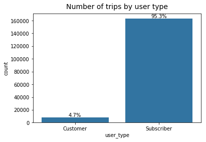

```python
# create the plot
plt.figure(figsize=(6,4))
base_color = sb.color_palette()[0]
sb.countplot(data = bikes, x = 'user_type', color = base_color)

# add annotations
plt.title('Number of trips by user type', fontsize=14, y=1.015)
n_points = bikes.shape[0]
cat_counts = bikes['user_type'].value_counts()
locs, labels = plt.xticks() # get the current tick locations and labels


# loop through each pair of locations and labels
for loc, label in zip(locs, labels):

    # get the text property for the label to get the correct count
    count = cat_counts[label.get_text()]
    pct_string = '{:0.1f}%'.format(100*count/n_points)

    # print the annotation just below the top of the bar
    plt.text(loc, count-8, pct_string, ha = 'center', color = 'black',va='bottom')
```

The participation of customer travel frequencies is not significant in relation to subscriber trips.

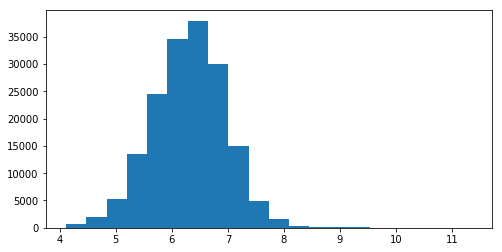

```python
plt.figure(figsize = [8,4])
base_color = sb.color_palette()[0]
ax=bikes['duration_sec_log'].hist(bins=20)
ax.grid(False)
```

The log transformation was chosed as the best one while wrangling data. I have compared log, square root and cube root.

## Outliers

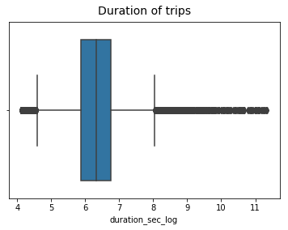

```python
sb.boxplot(x=bikes['duration_sec_log'])
plt.title('Duration of trips', fontsize=14, y=1.015)
```

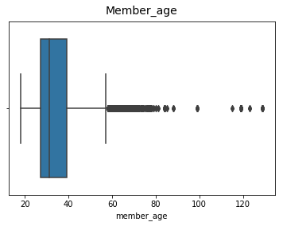

```python
bikes['member_age'] = bikes.member_age.astype(float)
sb.boxplot(x=bikes['member_age'])
plt.title('Member_age', fontsize=14, y=1.015)
```

Member_age equal or bigger than 60 years are outliers.

### Learning with the errors

In a bivariate exploration for outliers, I compare member_age depending on the gender of the user.

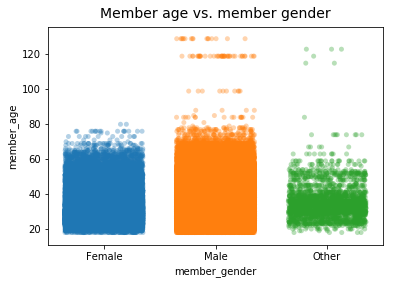

```python
# create a numeric variable from the string 'member_age'
# variable
bikes['member_age'] = bikes.member_age.astype(float)
# scatterplot (jittered) - age and gender
sb.stripplot(data = bikes, x = 'member_gender', y = 'member_age',
           jitter = 0.35 , alpha =  1/3);
plt.title('Member age vs. member gender', fontsize=14, y=1.015)
```

Comparing the two variable apparently with more outliers with a scatter graph, people said as Male and as Others has errors greater than people said as Female.  
Interestingly, it seems that only women are careful when entering the birth age and do not make gross mistakes. The genders men and others are said to be older than not just the outlier (60 years old) but also than the life expectancy in the USA (78 years old).

### Of the features you investigated, were there any unusual distributions? Did you perform any operations on the data to tidy, adjust, or change the form of the data? If so, why did you do this?

I a previous stage of data wrangling, I have dropped columns of the stations (coordinates), and I created columns of age, age group and weekdays.  
The distance seems not to be a good variable, because we don't know the routes used. These distances in a straight line, as calculated here, do not match reality. Another weakness here is that some trip starts and finish in the same place after a long time-trip.

## Bivariate Exploration

> In this section, I investigate relationships between pairs of variables in your data. Make sure the variables that you cover here have been introduced in some fashion in the previous section (univariate exploration).

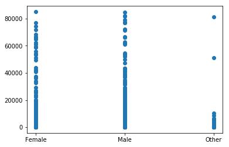

```python
plt.scatter(data = bikes, x = 'member_gender',y = 'duration_sec')
```

It seems that most genders have more short trips, in time (less than 20000 seconds). Others almost ever take short trips.

```python
bikes.dtypes
```

```
duration_sec                  int64
weekdays_start             category
start_station_name           object
end_station_name             object
bike_id                       int64
user_type                  category
member_gender              category
bike_share_for_all_trip      object
duration_sec_log            float64
duration_sec_sqrt           float64
duration_sec_cbrt           float64
member_age                  float64
age_grouped                category
member_age_new              float64
dtype: object
```

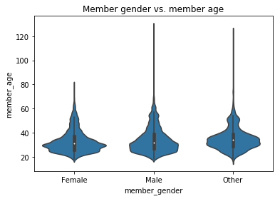

```python
sb.violinplot(data = bikes, x = 'member_gender', y = 'member_age',color=base_color)
plt.title('Member gender vs. member age')
```

The violin graph shows that most occurrences of Male and Female are by person between 25 and 30.

```python
fig, ((ax1, ax2), (ax3, ax4)) = plt.subplots(nrows=2, ncols=2,figsize = [14,8])
base_color = sb.color_palette()[0]
plt.suptitle('Analysis of users', fontsize=14, y=1.025)

ax1 = plt.subplot(2,2,1)
ax1=sb.countplot(data = bikes, x = 'member_gender', hue = 'age_grouped')
ax1= plt.xlabel("member's gender")
ax1= plt.ylabel('count of trips')

ax2 = plt.subplot(2,2,2)
ax2=sb.countplot(data = bikes, x = 'age_grouped', hue = 'member_gender')
ax2= plt.xlabel("member age's (grouped)")
ax2= plt.ylabel('count of trips')


ax3 = plt.subplot(2,2,3)
ax3=sb.countplot(data = bikes, x = 'user_type', hue = 'member_gender')
ax3= plt.xlabel('user type')
ax3= plt.ylabel('count of trips')

ax4 = plt.subplot(2,2,4)
ax4=sb.countplot(data = bikes, x = 'member_gender' , hue = 'user_type')
ax4= plt.xlabel("member's gender")
ax4= plt.ylabel('count of trips')

plt.tight_layout()
```

[output not shown]

**Account of trip in weekdays vs. age grouped, user type and mermber gender**

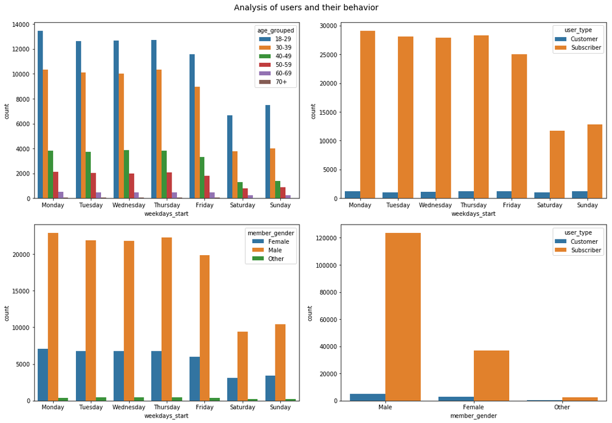

```python
#Accounts trip in weekdays vs. age grouped, user type and mermber gender
fig, ((ax1, ax2), (ax3, ax4)) = plt.subplots(nrows=2, ncols=2,figsize = [15,10])
base_color = sb.color_palette()[0]
plt.suptitle('Analysis of users and their behavior', fontsize=14, y=1.025)

plt.subplot(2, 2, 1)
sb.countplot(data = bikes, x = 'weekdays_start', hue = 'age_grouped',
             order = ['Monday','Tuesday','Wednesday','Thursday','Friday','Saturday','Sunday'])
plt.subplot(2, 2, 2)
sb.countplot(data = bikes, x = 'weekdays_start', hue = 'user_type',
             order = ['Monday','Tuesday','Wednesday','Thursday','Friday','Saturday','Sunday'])
plt.subplot(2, 2, 3)
sb.countplot(data = bikes, x = 'weekdays_start', hue = 'member_gender',
             order = ['Monday','Tuesday','Wednesday','Thursday','Friday','Saturday','Sunday'])

plt.subplot(2, 2, 4)
sb.countplot(data = bikes, x = 'member_gender', hue = 'user_type',
             order = ['Male','Female','Other'])

plt.tight_layout()
```

### Talk about some of the relationships you observed in this part of the investigation. How did the feature(s) of interest vary with other features in the dataset?

People between 18 and 39 years old are majority in trips. Men are majority among users compared to other genders. The percentage of subscribers are high is both genders. The trip number of subscribers is much higher than customers. The trip number of subscriber customers is stable during the weekdays. Workdays have higher demand for bikes, while Saturday has the lower demand, considering the number of trips.

### Did you observe any interesting relationships between the other features (not the main feature(s) of interest)?

The difference in the occurrence of outliers in age as a function of gender. I think this would be an interesting study in the future.

```
numeric_vars = ['duration_sec_log','member_age']
categoric_vars = ['weekdays_start', 'user_type', 'member_gender']
numeric_vars:
quantitative_contiguous = ['duration_sec', 'duration_sec_log',
'duration_min', 'member_age','bike_id']
quantitative_contiguous = ['start_time', 'end_time']
quantitative_binarious = ['bike_share_for_all_trip']
categoric_vars:
categoric_ordinal = ['weekdays_start', 'user_type', 'member_gender', 'age_grouped']
categoric_nominal = [start_station_name, end_station_name]
```

**The pairplot below correlates numeric and categorical variables**

```python
samples_bikes = np.random.choice(bikes.shape[0], 500, replace = False)
bikes_samp500 = bikes.loc[samples_bikes,:]
```

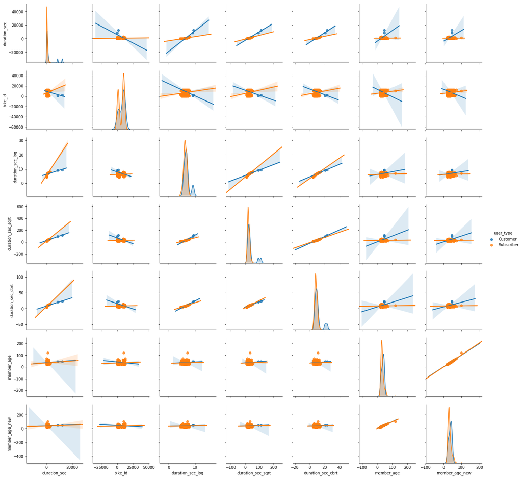

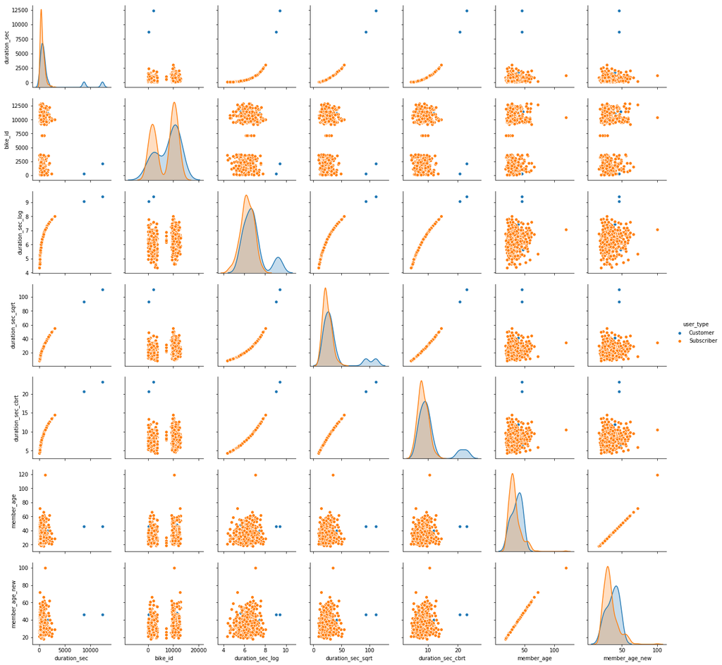

```python
plt.figure(figsize = [21, 10])
# with regression
sb.pairplot(bikes_samp500, kind="reg",hue="user_type")
plt.show()

# without regression
sb.pairplot(bikes_samp500, kind="scatter",hue="user_type")
plt.show()
```

**Numeric features ('duration_sec_log', 'member_age') vs. categorical variables**

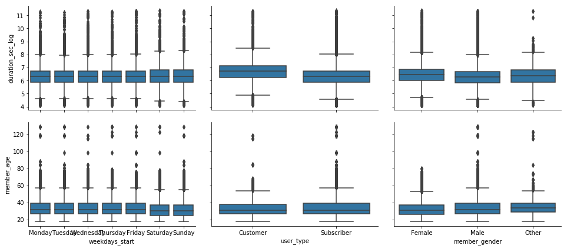

```python
# plot matrix of numeric features against categorical features.
# can use a larger sample since there are fewer plots and they're simpler in nature.

#samples = np.random.choice(bikes.shape[0], 2000, replace = False)
#bikes_samp = bikes.loc[samples,:]

def boxgrid(x, y, **kwargs):
    default_color = sb.color_palette()[0]
    sb.boxplot(x, y, color = default_color)

plt.figure(figsize = [10, 10])
g = sb.PairGrid(data = bikes, y_vars = ['duration_sec_log', 'member_age'], x_vars = categoric_vars,
                height = 3, aspect = 1.5)
g.map(boxgrid)
plt.show();
```

There is no negative relationships between the categorical variables and the numeric variables of interest.

#### So, looking at relationships between the categorical features:

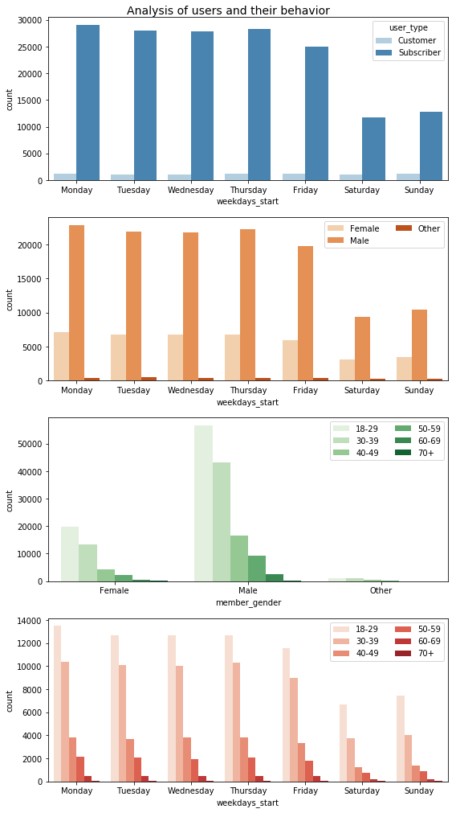

```python
# since there's only three subplots to create, using the full data should be fine.
fig, (ax1, ax2, ax3, ax4) = plt.subplots(nrows=1, ncols=4, figsize = [8,14])
plt.suptitle('Analysis of users and their behavior', fontsize=14, y=1)

# subplot 1: weekdays_start vs user_type
plt.subplot(4, 1, 1)
sb.countplot(data = bikes, x = 'weekdays_start', hue = 'user_type', palette = 'Blues')

# subplot 2: weekdays_start vs. member_gender
ax = plt.subplot(4, 1, 2)
sb.countplot(data = bikes, x = 'weekdays_start', hue = 'member_gender', palette = 'Oranges')
ax.legend(ncol = 2) # re-arrange legend to reduce overlapping

# subplot 3: member_gender vs. age_grouped, use different color palette
ax = plt.subplot(4, 1, 3)
sb.countplot(data = bikes, x = 'member_gender', hue = 'age_grouped', palette = 'Greens')
ax.legend(loc = 1, ncol = 2) # re-arrange legend to remove overlapping

# subplot 4: weekdays_start vs. age_grouped, use different color palette
ax = plt.subplot(4, 1, 4)
sb.countplot(data = bikes, x = 'weekdays_start', hue = 'age_grouped', palette = 'Reds')
ax.legend(loc = 1, ncol = 2) # re-arrange legend to remove overlapping

plt.tight_layout()
plt.show()
```

The graphs above don't bring news if compared with a previous one.

```python
bikes.dtypes
```

```
duration_sec                  int64
weekdays_start             category
start_station_name           object
end_station_name             object
bike_id                       int64
user_type                  category
member_gender              category
bike_share_for_all_trip      object
duration_sec_log            float64
duration_sec_sqrt           float64
duration_sec_cbrt           float64
member_age                  float64
age_grouped                category
member_age_new              float64
dtype: object
```

## Multivariate Exploration

**I made multivariate exploration focusing on the variables duration_sec_log, member_age, bike_share_for_all_trip and user_type.**  
I made another cleaning in the dataset.

```python
bikes_small = bikes.drop(columns=['duration_sec', 'bike_id'])

##numeric_vars = ['duration_sec_log','member_age']
##categoric_vars = ['weekdays_start', 'user_type', 'member_gender']
#numeric_vars:
#quantitative_contiguous = ['duration_sec', 'duration_sec_log',
#'duration_min', 'member_age','bike_id']
#quantitative_contiguous = ['start_time', 'end_time']
#quantitative_binarious = ['bike_share_for_all_trip']

#categoric_vars:
#categoric_ordinal = ['weekdays_start', 'user_type', 'member_gender', 'age_grouped']
#categoric_nominal = [start_station_name, end_station_name]
```

```python
bikes_small.head(3)
```

|  | weekdays_start | start_station_name | end_station_name | user_type | member_gender | bike_share_for_all_trip | duration_sec_log | duration_sec_sqrt | duration_sec_cbrt | member_age | age_grouped | member_age_new |
| --- | --- | --- | --- | --- | --- | --- | --- | --- | --- | --- | --- | --- |
| 0 | Monday | San Francisco Caltrain Station (King St at 4th... | San Francisco Caltrain Station (King St at 4th... | Customer | Female | No | 11.016381 | 246.704276 | 39.335480 | 29.0 | 18-29 | 29.0 |
| 1 | Monday | Jones St at Post St | Cyril Magnin St at Ellis St | Customer | Male | No | 8.633197 | 74.933304 | 17.773921 | 34.0 | 30-39 | 34.0 |
| 2 | Monday | Sanchez St at 15th St | Valencia St at 21st St | Subscriber | Male | No | 7.148346 | 35.665109 | 10.835003 | 30.0 | 18-29 | 30.0 |

**Creating samples to reduce the time of run.**

```python
#samples = np.random.choice(bikes_small.shape[0], 2000, replace = False)
#bikes_samp2000 = bikes_small.loc[samples,:]
samples = np.random.choice(bikes_small.shape[0], 500, replace = False)
bikes_samp500 = bikes_small.loc[samples,:]
```

**Comparing numerical variables and a categorical one.**

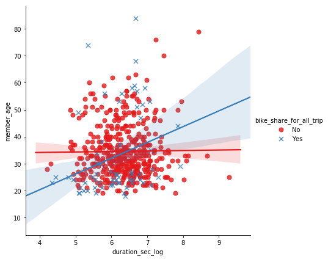

```python
g = sb.lmplot(x="duration_sec_log", y="member_age", hue="bike_share_for_all_trip", data=bikes_samp500, palette="Set1",
              markers=["o","x"], scatter_kws={"s": 50}, height=6)
```

The older the member who shares the bike for the entire trip, the longer the trip.

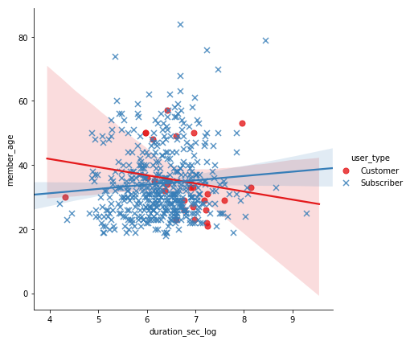

```python
g = sb.lmplot(x="duration_sec_log", y="member_age", hue="user_type", data=bikes_samp500, palette="Set1",
              markers=["o","x"], scatter_kws={"s": 50}, height=6)
```

Subscriber urers are a bit older than the customers.

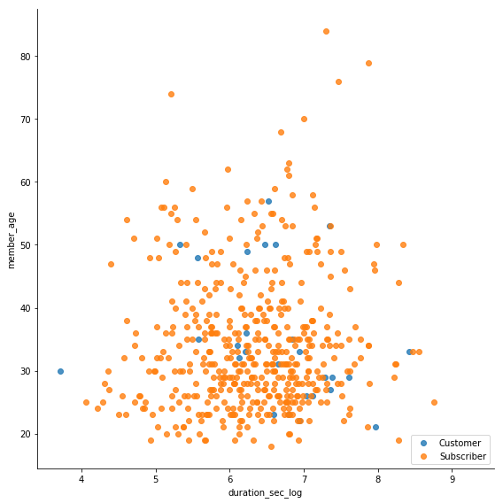

```python
plt.figure(figsize = [6, 6])
#numeric_vars = ['duration_sec_log','member_age']
#categoric_vars = ['weekdays_start', 'user_type', 'member_gender']

# Use the 'hue' argument to provide a factor variable
sb.lmplot( x="duration_sec_log", y="member_age", data=bikes_samp500, fit_reg=False, hue='user_type',
          legend=False,x_jitter=.75,height = 8)

# Move the legend to an empty part of the plot
plt.legend(loc='lower right')
```

The correlation among member age and duration_sec_log does not present any interesting result.

The correlation among member age and duration_sec_log does not present any interesting result. Subscriber urers are a bit older than the customers.

```python
bikes.info()
```

```
<class 'pandas.core.frame.DataFrame'>
RangeIndex: 170999 entries, 0 to 170998
Data columns (total 14 columns):
duration_sec               170999 non-null int64
weekdays_start             170999 non-null category
start_station_name         170999 non-null object
end_station_name           170999 non-null object
bike_id                    170999 non-null int64
user_type                  170999 non-null category
member_gender              170999 non-null category
bike_share_for_all_trip    170999 non-null object
duration_sec_log           170999 non-null float64
duration_sec_sqrt          170999 non-null float64
duration_sec_cbrt          170999 non-null float64
member_age                 170999 non-null float64
age_grouped                170980 non-null category
member_age_new             170999 non-null float64
dtypes: category(4), float64(5), int64(2), object(3)
memory usage: 13.7+ MB
```

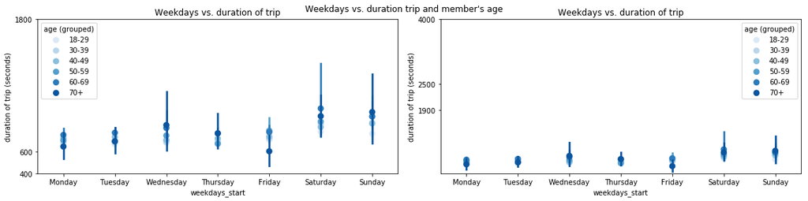

```python
plt.figure(figsize = [16,4])
plt.suptitle("Weekdays vs. duration trip and member's age")

ax1=plt.subplot(1,2, 1)
ax1=sb.pointplot(data = bikes, x= 'weekdays_start', y = 'duration_sec',
                 hue = 'age_grouped', palette = 'Blues', linestyles = '')
ax1=plt.ylabel('duration of trip (seconds)')
ax1=plt.title('Weekdays vs. duration of trip')
ax1=plt.yticks([400, 600, 1800]) # 30 minutes
ax1=plt.legend(title='age (grouped)')

ax2=plt.subplot(1, 2, 2)
ax2=sb.pointplot(data = bikes, x= 'weekdays_start', y = 'duration_sec',
                 hue = 'age_grouped', palette = 'Blues', linestyles = '')
ax2=plt.ylabel('duration of trip (seconds)')
ax2=plt.title('Weekdays vs. duration of trip')
ax2=plt.yticks([1.9e3, 2.5e3, 4e3])
ax2=plt.legend(title='age (grouped)')

plt.tight_layout()
```

There are less longer trips, specially in workdays. The duration of trip of youngers is more stable than the olders, these have higher variation. Strangely, the behavior of 70+ change on Wednesdays and om Fridays.

**Comparing a categorical variable with two numerical variables**

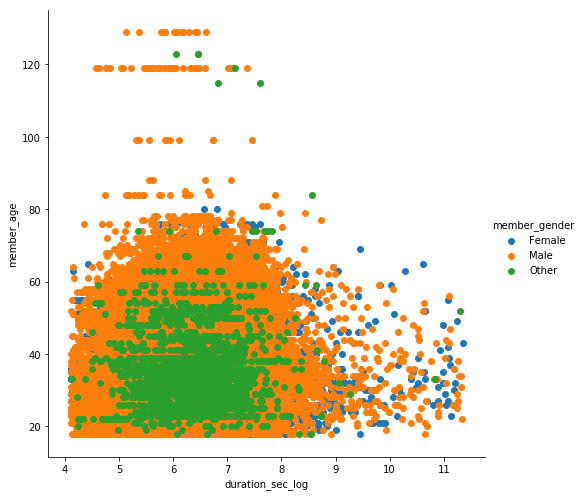

```python
g = sb.FacetGrid(data = bikes, hue = 'member_gender', height = 7)
g.map(plt.scatter, 'duration_sec_log', 'member_age')
g.add_legend()
```

This graph highlights the ouliers in member_age, mainly for men.

```python
print(bikes.describe())
print(bikes.info())
```

```
        duration_sec        bike_id  duration_sec_log  duration_sec_sqrt  \
count  170999.000000  170999.000000     170999.000000      170999.000000
mean      713.529763    7286.698413          6.308851          24.825320
std      1402.360424    4404.651340          0.664465           9.860721
min        61.000000      12.000000          4.110874           7.810250
25%       358.000000    2446.000000          5.880533          18.920888
50%       560.000000    9777.000000          6.327937          23.664319
75%       851.000000   10636.000000          6.746412          29.171904
max     85035.000000   13007.000000         11.350818         291.607613

       duration_sec_cbrt     member_age  member_age_new
count      170999.000000  170999.000000   170999.000000
mean            8.397959      33.914947       33.906988
std             1.997118      10.155251       10.094445
min             3.936497      18.000000       18.000000
25%             7.100588      27.000000       27.000000
50%             8.242571      31.000000       31.000000
75%             9.476396      39.000000       39.000000
max            43.974331     129.000000      100.000000
<class 'pandas.core.frame.DataFrame'>
RangeIndex: 170999 entries, 0 to 170998
Data columns (total 14 columns):
duration_sec               170999 non-null int64
weekdays_start             170999 non-null category
start_station_name         170999 non-null object
end_station_name           170999 non-null object
bike_id                    170999 non-null int64
user_type                  170999 non-null category
member_gender              170999 non-null category
bike_share_for_all_trip    170999 non-null object
duration_sec_log           170999 non-null float64
duration_sec_sqrt          170999 non-null float64
duration_sec_cbrt          170999 non-null float64
member_age                 170999 non-null float64
age_grouped                170980 non-null category
member_age_new             170999 non-null float64
dtypes: category(4), float64(5), int64(2), object(3)
memory usage: 13.7+ MB
None
```

**Weekdays vs. duration trip and members' age**

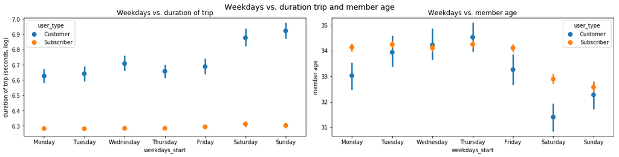

```python
fig, (ax1, ax2) = plt.subplots(nrows=1, ncols=2, figsize = [16,4])
plt.suptitle('Weekdays vs. duration trip and member age', fontsize=14, y=1)

ax1=plt.subplot(1, 2, 1)
ax1=sb.pointplot(data = bikes, x= 'weekdays_start', y = 'duration_sec_log',
                 hue = 'user_type', linestyles = "")
ax1=plt.ylabel('duration of trip (seconds, log)')
ax1=plt.title('Weekdays vs. duration of trip')

ax2=plt.subplot(1, 2, 2)
ax2=sb.pointplot(data = bikes, x= 'weekdays_start', y = 'member_age',
                 hue = 'user_type', linestyles = "")
ax2=plt.ylabel('member age')
ax2=plt.title('Weekdays vs. member age')

plt.tight_layout()
```

Trips on weekens are longer. Users on weekend are a bit younger.

```python
start_station_count  = bikes['start_station_name'].value_counts()
start_station_count = start_station_count[:5,]
start_station_count
```

```
San Francisco Caltrain (Townsend St at 4th St)      4278
Market St at 10th St                                2927
Berry St at 4th St                                  2852
Montgomery St BART Station (Market St at 2nd St)    2415
Howard St at Beale St                               2414
Name: start_station_name, dtype: int64
```

```python
end_station_count  = bikes['end_station_name'].value_counts()
end_station_count = start_station_count[:5,]
end_station_count
```

```
San Francisco Caltrain (Townsend St at 4th St)      4278
Market St at 10th St                                2927
Berry St at 4th St                                  2852
Montgomery St BART Station (Market St at 2nd St)    2415
Howard St at Beale St                               2414
Name: start_station_name, dtype: int64
```

### Were there any interesting or surprising interactions between features?

The older the member who shares the bike for the entire trip, the longer the trip. Subscriber users are a bit older than the customers. The correlation among member age and duration_sec_log does not present any interesting result. There are less longer trips, specially in workdays. The duration of trip by younger people is more stable than the older, these have higher variation. Strangely, the behavior of 70+ change on Wednesdays and om Fridays.